# Single Heatmap

A single heatmap is the most used way for visualizing the data. Although “the shining point” of the **ComplexHeatmap** package is it can visualize a list of heatmaps in parallel, as the basic unit of the heatmap list, it is still very important to have the single heatmap nicely configured.

First let's generate a random matrix where there are three groups by columns and three groups by rows:

```r
set.seed(123)
nr1 = 4; nr2 = 8; nr3 = 6; nr = nr1 + nr2 + nr3
nc1 = 6; nc2 = 8; nc3 = 10; nc = nc1 + nc2 + nc3
mat = cbind(rbind(matrix(rnorm(nr1*nc1, mean = 1,   sd = 0.5), nr = nr1),
          matrix(rnorm(nr2*nc1, mean = 0,   sd = 0.5), nr = nr2),
          matrix(rnorm(nr3*nc1, mean = 0,   sd = 0.5), nr = nr3)),
    rbind(matrix(rnorm(nr1*nc2, mean = 0,   sd = 0.5), nr = nr1),
          matrix(rnorm(nr2*nc2, mean = 1,   sd = 0.5), nr = nr2),
          matrix(rnorm(nr3*nc2, mean = 0,   sd = 0.5), nr = nr3)),
    rbind(matrix(rnorm(nr1*nc3, mean = 0.5, sd = 0.5), nr = nr1),
          matrix(rnorm(nr2*nc3, mean = 0.5, sd = 0.5), nr = nr2),
          matrix(rnorm(nr3*nc3, mean = 1,   sd = 0.5), nr = nr3))
   )
mat = mat[sample(nr, nr), sample(nc, nc)] # random shuffle rows and columns
rownames(mat) = paste0("row", seq_len(nr))
colnames(mat) = paste0("column", seq_len(nc))
```

Following command contains the minimal argument for the `Heatmap()` function which just visualizes the matrix as a heatmap with default settings. Very similar as other heatmap tools, it draws the dendrograms, the row/column names and the heatmap legend. The default color schema is “blue-white-red” which is mapped to the minimal-mean-maximal values in the matrix. The title for the legend is assigned by an internal index number.

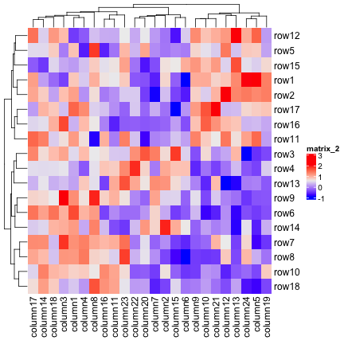

```r
Heatmap(mat)
```

The title for the legend is taken from the “name” of the heatmap by default. Each heatmap has a name which is like a unique identifier for the heatmap, which is important when you have a list of heatmaps. In later chapters, you will find the heatmap name is used for setting the “main heatmap” and is used for decoration of heatmaps. If the name is not assigned, an internal name is assigned to the heatmap in a form of `matrix_%d`. In following examples in this chapter, we give the name `mat` to the heatmap (for which you will see the change of the legend in next plot).

## Colors

For heatmap visualization, colors are the major representation of the data matrix. In most cases, the heatmap visualizes a matrix with continuous numeric values. In this case, users should provide a color mapping function. A color mapping function should accept a vector of values and return a vector of corresponding colors. **Users should always use `circlize::colorRamp2()` function to generate the color mapping function**. The two arguments for `colorRamp2()` is a vector of break values and a vector of corresponding colors. `colorRamp2()` linearly interpolates colors in every interval through LAB color space. Also using `colorRamp2()` helps to generate a legend with proper tick marks.

In following example, values between -2 and 2 are linearly interpolated to get corresponding colors, values larger than 2 are all mapped to red and values less than -2 are all mapped to green.

```r
library(circlize)
col_fun = colorRamp2(c(-2, 0, 2), c("green", "white", "red"))
col_fun(seq(-3, 3))
```

```
## [1] "#00FF00FF" "#00FF00FF" "#B1FF9AFF" "#FFFFFFFF" "#FF9E81FF" "#FF0000FF"
## [7] "#FF0000FF"
```

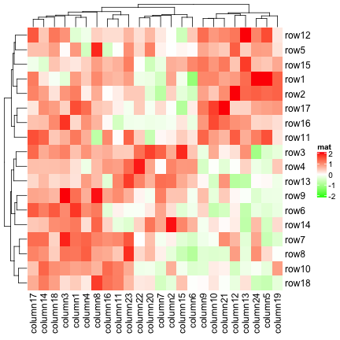

```r
Heatmap(mat, name = "mat", col = col_fun)
```

As you can see, the color mapping function exactly maps negative values to green and positive values to red, even when the distribution of negative values and positive values are not centric to zero. Also this color mapping function is not affected by outliers. In following plot, the clustering is heavily affected by the outlier but not the color mapping.

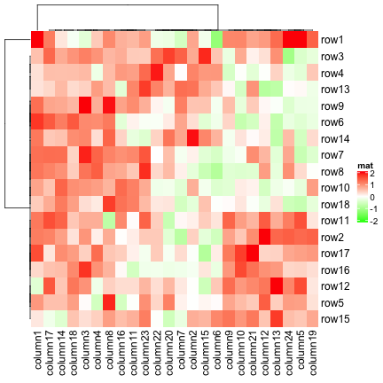

```r
mat2 = mat
mat2[1, 1] = 100000
Heatmap(mat2, name = "mat", col = col_fun)
```

More importantly, `colorRamp2()` makes colors in multiple heatmaps comparible if they are set with a same color mapping function.

If the matrix is continuous, you can simply provide a vector of colors and colors will be linearly interpolated. But remember this method is not robust to outliers because the mapping starts from the minimal value in the matrix and ends with the maximal value. Following color mapping setting is identical to `colorRamp2(seq(min(mat), max(mat), length = 10), rev(rainbow(10)))`.

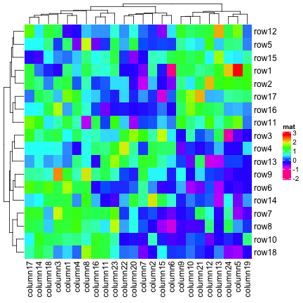

```r
Heatmap(mat, name = "mat", col = rev(rainbow(10)))
```

If the matrix contains discrete values (either numeric or character), colors should be specified as a named vector to make it possible for the mapping from discrete values to colors. If there is no name for the color, the order of colors corresponds to the order of `unique(mat)`. Note the legend is generated from the color mapping vector.

Following sets colors for a discrete numeric matrix (you don't need to convert it to a character matrix).

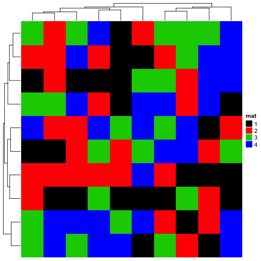

```r
discrete_mat = matrix(sample(1:4, 100, replace = TRUE), 10, 10)
colors = structure(1:4, names = c("1", "2", "3", "4")) # black, red, green, blue
Heatmap(discrete_mat, name = "mat", col = colors)
```

Or a character matrix:

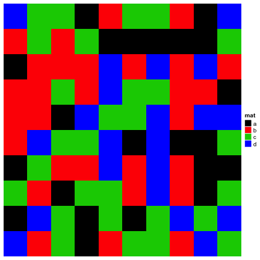

```r
discrete_mat = matrix(sample(letters[1:4], 100, replace = TRUE), 10, 10)
colors = structure(1:4, names = letters[1:4])
Heatmap(discrete_mat, name = "mat", col = colors)
```

As you see in the above examples, for the numeric matrix (no matter it is continuous mapping or discrete mapping), by default clustering is applied on both dimensions while for character matrix, clustering is turned off.

`NA` is allowed in the heatmap. You can control the color of `NA` by `na_col` argument (by default it is grey for `NA`). **The matrix which contains `NA` can also be clustered by `Heatmap()`.**

Note the `NA` value is not presended in the legend.

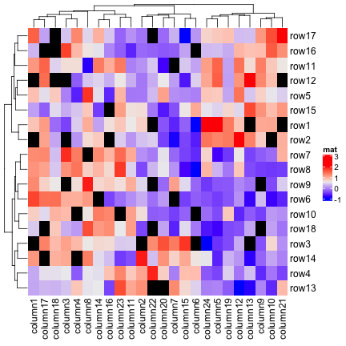

```r
mat_with_na = mat
mat_with_na[sample(c(TRUE, FALSE), nrow(mat)*ncol(mat), replace = TRUE, prob = c(1, 9))] = NA
Heatmap(mat_with_na, name = "mat", na_col = "black")
```

Color space is important for interpolating colors. By default, colors are linearly interpolated in [LAB color space](https://en.wikipedia.org/wiki/Lab_color_space), but you can select the color space in `colorRamp2()` function. Compare following two plots. Can you see the difference?

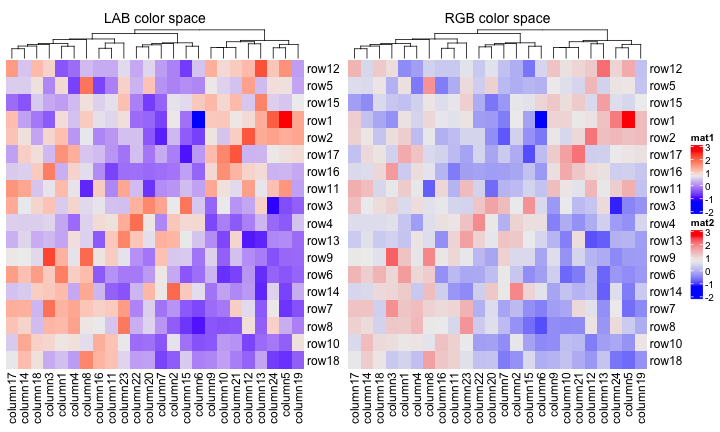

```r
f1 = colorRamp2(seq(min(mat), max(mat), length = 3), c("blue", "#EEEEEE", "red"))
f2 = colorRamp2(seq(min(mat), max(mat), length = 3), c("blue", "#EEEEEE", "red"), space = "RGB")
Heatmap(mat, name = "mat1", col = f1, column_title = "LAB color space", show_row_dend = FALSE) +
Heatmap(mat, name = "mat2", col = f2, column_title = "RGB color space")
```

In following figures, corresponding values change evenly on the folded lines, you can see how colors change under different color spaces (the plot is made by [**HilbertCurve** package](https://bioconductor.org/packages/release/bioc/html/HilbertCurve.html)).

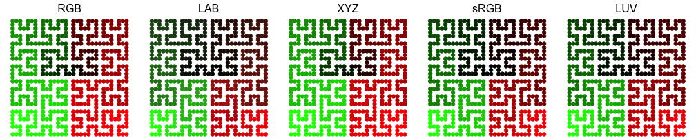

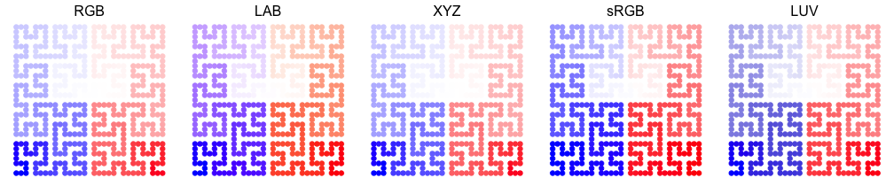

Last but not the least, colors for the heatmap borders can be set by the `border` and `rect_gp` arguments. `border` controls the global border of the heatmap body and `rect_gp` controls the border of the grids in the heatmap.

The value of `border` can be logical (`TRUE` corresponds to `black`) or a character of color (e.g. `red`).

`rect_gp` is a `gpar` object which means you can only set it by `grid::gpar()`. Since the filled color is already controlled by the heatmap color mapping, you can only set the `col` parameter in `gpar()` to control the border of the heatmap grids.

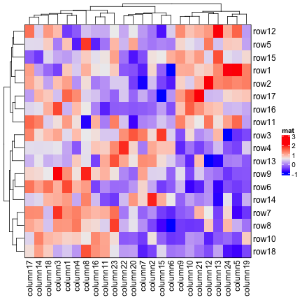

```r
Heatmap(mat, name = "mat", border = TRUE)
```

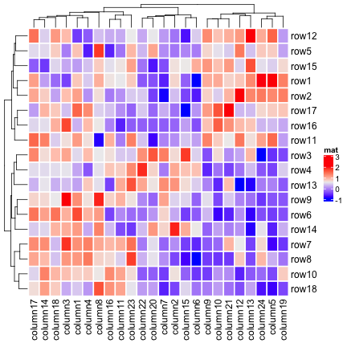

```r
Heatmap(mat, name = "mat", rect_gp = gpar(col = "white", lwd = 2))
```

## Titles

The title of the heatmap basically tells what the plot is about. In **ComplexHeatmap** package, you can set heatmap title either by the row or/and on the column. Note at a same time you can only put e.g. column title either on the top or at the bottom of the heatmap (because it is somehow weird to have both a top column title and a bottom column title)

The graphic parameters can be set by `row_title_gp` and `column_title_gp` respectively. Please remember you should use `gpar()` to specify graphic parameters.

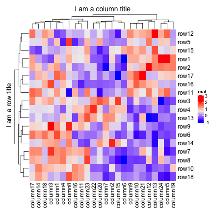

```r
Heatmap(mat, name = "mat", column_title = "I am a column title", row_title = "I am a row title")
```

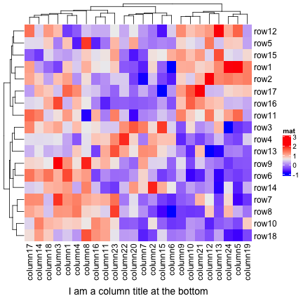

```r
Heatmap(mat, name = "mat", column_title = "I am a column title at the bottom",
    column_title_side = "bottom")
```

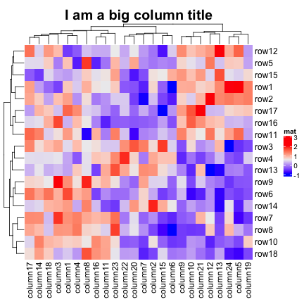

```r
Heatmap(mat, name = "mat", column_title = "I am a big column title",
    column_title_gp = gpar(fontsize = 20, fontface = "bold"))
```

Rotations for titles can be set by `row_title_rot` and `column_title_rot`, but only horizontal and vertical rotations are allowed.

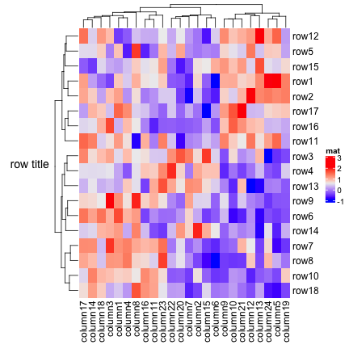

```r
Heatmap(mat, name = "mat", row_title = "row title", row_title_rot = 0)
```

```r
# code only for demonstration
Heatmap(mat, name = "mat", row_km = 2, row_title = "cluster_%s") # row title would be cluster_1 and cluster_2
```

You can set `fill` parameter in `row_title_gp` and `column_title_gp` to set the background of titles.

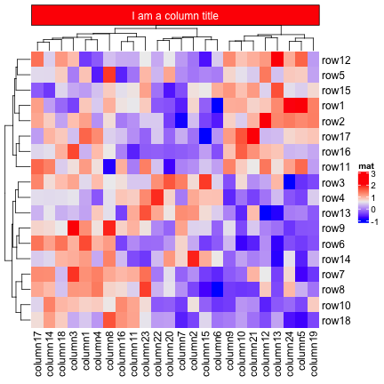

```r
Heatmap(mat, name = "mat", column_title = "I am a column title",
    column_title_gp = gpar(fill = "red", col = "white"))
```

## Clustering

Clustering might be the key component of the heatmap visualization. In **ComplexHeatmap** package, Hierarchical clustering is supported with high flexibility. You can specify the clustering either by:

- a pre-defined distance method (e.g. `eulidean` or `pearson`),
- a distance function,
- a object that already contains clustering (a `hclust` or `dendrogram` object or object that can be coerced to `hclust` or `dendrogram` class),
- a clustering function.

It is also possible to render the dendrograms with different colors and styles for different branches for better revealing structures of your data (e.g. by `dendextend::color_branches()`).

First, there are general settings for the clustering, e.g. whether apply clustering or show dendrograms, the side of the dendrograms and heights of the dendrograms.

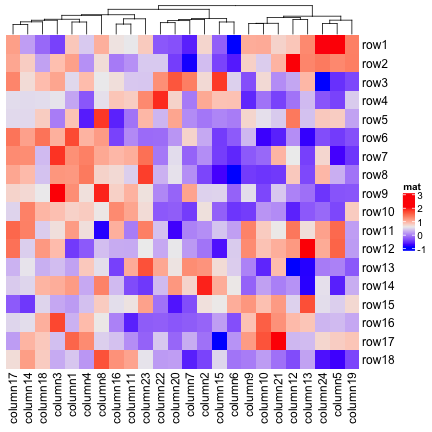

```r
Heatmap(mat, name = "mat", cluster_rows = FALSE) # turn off row clustering
```

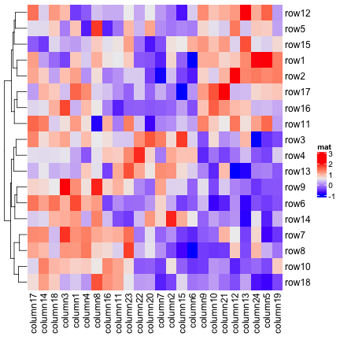

```r
Heatmap(mat, name = "mat", show_column_dend = FALSE) # hide column dendrogram
```

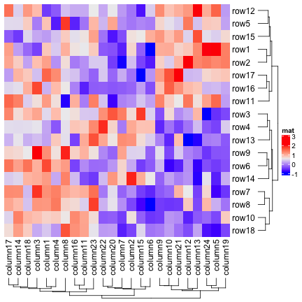

```r
Heatmap(mat, name = "mat", row_dend_side = "right", column_dend_side = "bottom")
```

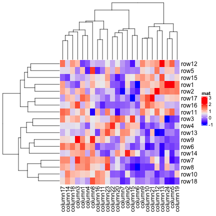

```r
Heatmap(mat, name = "mat", column_dend_height = unit(4, "cm"), row_dend_width = unit(4, "cm"))
```

### Distance methods

Hierarchical clustering is performed in two steps: calculate the distance matrix and apply clustering. There are three ways to specify distance metric for clustering:

- specify distance as a pre-defined option. The valid values are the supported methods in `dist()` function and in `pearson`, `spearman` and `kendall`. If there is any `NA` values in the matrix, `ComplexHeatmap::dist2()` is used instead which performs pairwise distance calculation by removing `NA` values. The correlation distance is defined as `1 - cor(x, y, method)`.
- a self-defined function which calculates distance from a matrix. The function should only contain one argument. Please note for clustering on columns, the matrix will be transposed automatically.
- a self-defined function which calculates distance from two vectors. The function should only contain two arguments.

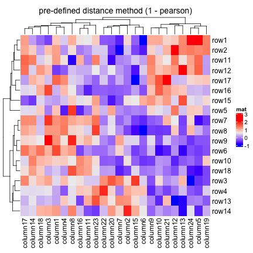

```r
Heatmap(mat, name = "mat", clustering_distance_rows = "pearson",
    column_title = "pre-defined distance method (1 - pearson)")
```

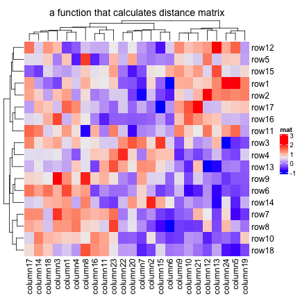

```r
Heatmap(mat, name = "mat", clustering_distance_rows = function(m) dist(m),
    column_title = "a function that calculates distance matrix")
```

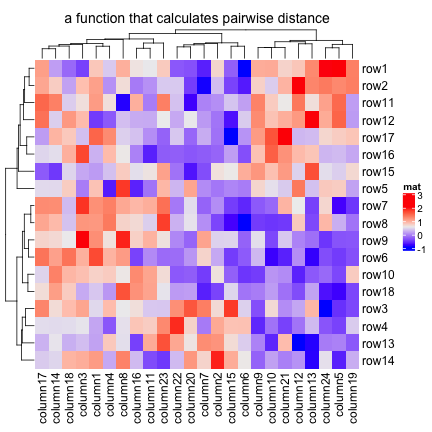

```r
Heatmap(mat, name = "mat", clustering_distance_rows = function(x, y) 1 - cor(x, y),
    column_title = "a function that calculates pairwise distance")
```

Based on these features, we can apply clustering which is robust to outliers based on the pairwise distance. Note here we set the color mapping function because we don't want to outliers affect the colors.

```r
mat_with_outliers = mat
for(i in  1:10) mat_with_outliers[i, i] = 1000
robust_dist = function(x, y) {
    qx = quantile(x, c(0.1, 0.9))
    qy = quantile(y, c(0.1, 0.9))
    l = x > qx[1] & x < qx[2] & y > qy[1] & y < qy[2]
    x = x[l]
    y = y[l]
    sqrt(sum((x - y)^2))
}
```

and we compare the two heatmaps with or without the robust version of distance method:

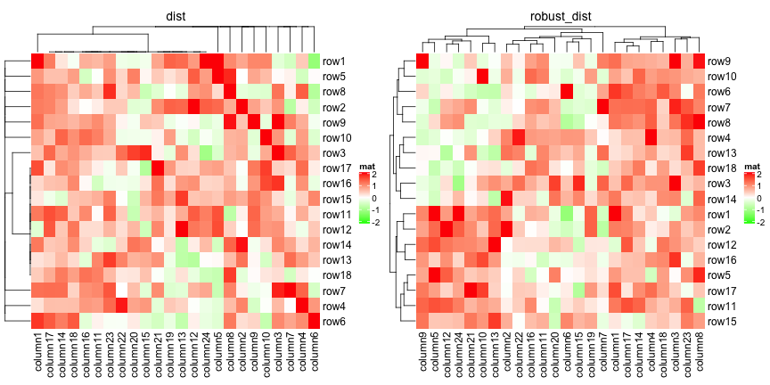

```r
Heatmap(mat_with_outliers, name = "mat",
    col = colorRamp2(c(-2, 0, 2), c("green", "white", "red")),
    column_title = "dist")
Heatmap(mat_with_outliers, name = "mat",
    col = colorRamp2(c(-2, 0, 2), c("green", "white", "red")),
    clustering_distance_rows = robust_dist,
    clustering_distance_columns = robust_dist,
    column_title = "robust_dist")
```

If there are proper distance methods (like methods in [**stringdist** package](https://cran.r-project.org/web/packages/stringdist/), you can also cluster a character matrix. `cell_fun` argument will be explained in later section.

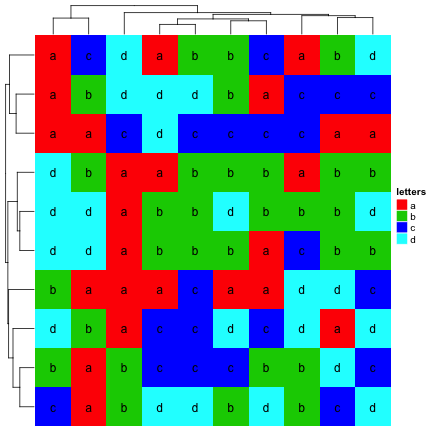

```r
mat_letters = matrix(sample(letters[1:4], 100, replace = TRUE), 10)
# distance in the ASCII table
dist_letters = function(x, y) {
    x = strtoi(charToRaw(paste(x, collapse = "")), base = 16)
    y = strtoi(charToRaw(paste(y, collapse = "")), base = 16)
    sqrt(sum((x - y)^2))
}
Heatmap(mat_letters, name = "letters", col = structure(2:5, names = letters[1:4]),
    clustering_distance_rows = dist_letters, clustering_distance_columns = dist_letters,
    cell_fun = function(j, i, x, y, w, h, col) { # add text to each grid
        grid.text(mat_letters[i, j], x, y)
    })
```

### Clustering methods

Method to perform hierarchical clustering can be specified by `clustering_method_rows` and `clustering_method_columns`. Possible methods are those supported in `hclust()` function.

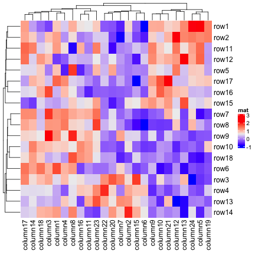

```r
Heatmap(mat, name = "mat", clustering_method_rows = "single")
```

If you already have clustering objects or a function which directly returns a clustering object, you can ignore the distance settings and set `cluster_rows` or `cluster_columns` to the clustering objects or clustering functions. If it is a clustering function, the only argument should be the matrix and it should return a `hclust` or `dendrogram` object or a object that can be coerced to the two classes.

In following example, we perform clustering with methods from **cluster** package either by a pre-calculated clustering object or a clustering function:

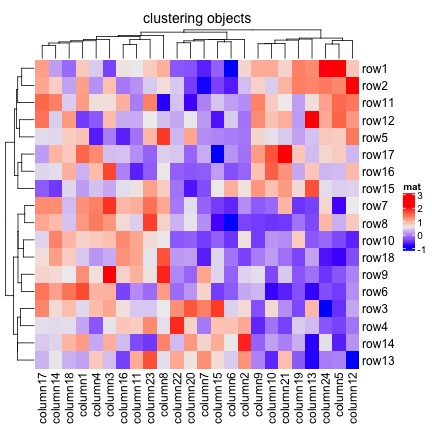

```r
library(cluster)
Heatmap(mat, name = "mat", cluster_rows = as.dendrogram(diana(mat)),
   cluster_columns = as.dendrogram(agnes(t(mat))), column_title = "clustering objects")
```

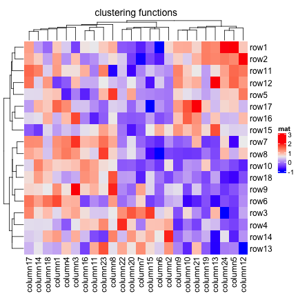

```r
Heatmap(mat, name = "mat", cluster_rows = diana,
   cluster_columns = agnes, column_title = "clustering functions")
```

The last command is as same as :

```r
# code only for demonstration
Heatmap(mat, name = "mat", cluster_rows = function(m) as.dendrogram(diana(m)),
    cluster_columns = function(m) as.dendrogram(agnes(m)), column_title = "clutering functions")
```

Please note, when `cluster_rows` is set as a function, the argument `m` is the input `mat` itself, while for `cluster_columns`, `m` is the transpose of `mat`.

`fastcluster::hclust` implements a faster version of `hclust`. We can set `cluster_rows` and `cluster_columns` to use the faster version of `hclust`.

```r
# code only for demonstration
Heatmap(mat, name = "mat", cluster_rows = fastcluster::hclust,
    cluster_columns = fastcluster::hclust)
```

To make it more convinient to use the faster version of `hclust` (assuming you have many heatmaps to construct), it can be set as a global option. The usage of `ht_opt` is introduced later.

```r
# code not run when building the vignette
ht_opt$fast_hclust = TRUE
# now fastcluster::hclust is used in all heatmaps
```

### Render dendrograms

You can render your `dendrogram` object by the **dendextend** package to make a more customized visualization of the dendrogram. Note **ComplexHeatmap** only allows rendering on the dendrogram edges.

If you want to render the dendrogram, normally you need to generate a `dendrogram` object and render it in the first place, then send it to the `cluster_rows` or `cluster_columns` argument.

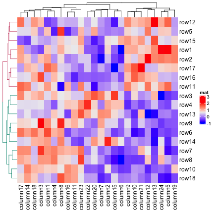

```r
library(dendextend)
row_dend = as.dendrogram(hclust(dist(mat)))
row_dend = color_branches(row_dend, k = 2)
Heatmap(mat, name = "mat", cluster_rows = row_dend)
```

### Reorder dendrograms

In the `Heatmap()` function, dendrograms are reordered to make features with larger difference more separated from each others (please refer to the documentation of `reorder.dendrogram()`). Here the difference is measured by the row means if it is a row dendrogram or by the column means if it is a column dendrogram. `row_dend_reorder` and `column_dend_reorder` control whether apply dendrogram reordering and the weight for the reordering (since `reorder.dendrogram()` needs a `wts` argument). The reordering can be turned off by setting e.g. `row_dend_reorder = FALSE`.

There are many other methods for reordering dendrograms, e.g. the **dendsort** package. Basically, all these methods still return a dendrogram which has been reordered, thus, we can firstly generate the row or column dendrogram based on the data matrix, reorder it by some method, and assign it back to `cluster_rows` or `cluster_columns`.

Compare following three heatmaps:

[output not shown]

[figure not shown]

```r
Heatmap(mat, name = "mat", row_dend_reorder = FALSE, column_title = "no reordering")
Heatmap(mat, name = "mat", row_dend_reorder = TRUE, column_title = "applied reordering")

library(dendsort)
dend = dendsort(as.dendrogram(hclust(dist(mat))))
draw(Heatmap(mat, name = "mat", cluster_rows = dend, row_dend_reorder = FALSE,
    column_title = "reordering by dendsort"))
```

## Row and column orders

Clustering is used to adjust row orders and column orders of the heatmap, but you can still set the order manually by `row_order` and `column_order`. If e.g. `row_order` is set, row clustering is turned off.

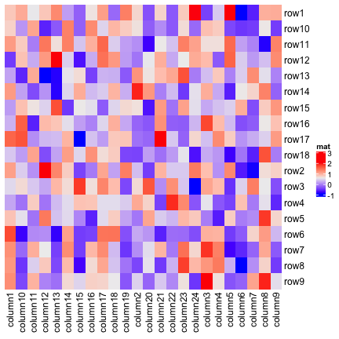

```r
Heatmap(mat, name = "mat", row_order = order(rownames(mat)), column_order = order(colnames(mat)))
```

Note `row_dend_reorder` and `row_order` are different. `row_dend_reorder` is applied on the dendrogram. For any node in the dendrogram, rotating its two branches actually gives an identical dendrogram, thus, reordering the dendrogram by automatically rotating sub-dendrogram at every node can help to separate elements further from each other which show more difference. As a comparison, `row_order` is simply applied on the matrix and normally dendrograms should be turned off.